# R Notebook

```r
library(dplyr)
library(ggplot2)
library(gridExtra)
library(MASS)
library(fitdistrplus)
library(ggstatsplot)
library(tibble)
library(readr)
```

# Proyecto de modelación integrado en etapas dentro de la notebook

## Etapa 1 - definición de los datos expuestos y no expuestos

Esta parte realiza la lectura de datos y los convierte en trame

```r
# confusoras DAG= "sl2l_qa", "sl2l_iso","ecpl_qa", "ecpl_iso","age", "gender_F",
# features predictoras = "sl2l_diameter","ccbd_diameter","ifol_diameter","ecpl_volume","tral_volume","sl2l_mean_length","ccbd_mean_length"

setwd("C:/hcgalvan/Repositorios/hcgalvan_project/data/union/End")
temp = gsub(".*target.*", "", readLines("integrado.csv"))
data<-read.table(text=temp, sep=",", header=TRUE)

t<-data.frame(data[,c("sl2l_diameter","ccbd_diameter","ifol_diameter","ecpl_volume","tral_volume","sl2l_mean_length","ccbd_mean_length","label","sl2l_qa", "sl2l_iso","ecpl_qa", "ecpl_iso","age", "gender_F")])

t$gend_F <- ifelse(t$gender_F == "True", 1, 0) #convierto en = o 1
t <- subset(t, select = -c(gender_F)) # Quito de tabla
```

### Creación de features expuestos y no expuestos

Definición de nuevas variables como Expuesto y no Expuesto Se realizó estudio de cada variable: Su real distribución empírica Esta distribución se obtiene de los sujetos de control. las constantes definidas son el 1ero y 3er cuartil obtenida de distribución de densidad

False = No Expuesto = 0; True = Expuesto = 1

```r
t<- t %>%
  mutate(sl2ldmExp = if_else((t$sl2l_diameter > 22.10 & t$sl2l_diameter < 24.42), 0, 1))

t<- t %>%
  mutate(ccbdmExp = if_else((t$ccbd_diameter > 14.68 & t$ccbd_diameter < 16.51), 0, 1))

t<- t %>%
  mutate(ifoldmExp = if_else((t$ifol_diameter > 14.68 & t$ifol_diameter < 16.51), 0, 1))

t<- t %>%
  mutate(ecplvlExp = if_else((t$ecpl_volume > 6455 & t$ecpl_volume < 8918), 0, 1))

t<- t %>%
  mutate(tralvlExp = if_else((t$tral_volume > 12366 & t$tral_volume < 18004), 0, 1))

t<- t %>%
  mutate(sl2lmlExp = if_else((t$sl2l_mean_length > 72.18 & t$sl2l_mean_length < 80.61), 0, 1))

t<- t %>%
  mutate(ccbdmlExp = if_else((t$ccbd_mean_length > 112.62 & t$ccbd_mean_length < 123.81), 0, 1))
```

### Guardar datos para su estudio en InfoStat

El estudio que realizo en InfoStat es para determinar que variable predictora debe estar en la regresión y continuar el estudio por R. InfoStat me arroja rapidamente cuales son las confusoras más importantes

Dependerá de variable A y las confusoras.

```r
write.csv(t, "C:\\hcgalvan\\Repositorios\\hcgalvan_project\\data\\union\\End\\dbfmodelo.csv", row.names=FALSE)
```

### Creación de variable A a partir de los expuestos y no expuestos

OPCION 1: Variable con A con 5 features filtrados como expuestos.

t<- t %>% mutate(A = if_else((t$sl2ldmExp==1 & t$sl2lmlExp==1 & t$ccbdmExp==1 & t$ccbdmlExp==1 & t$tralvlExp==1),1, 0)) # No agrego ecpl porque contiene mucho ruido

t<- t %>% mutate(A = if_else((t$sl2ldmExp==1 & t$sl2lmlExp==1 & t$ccbdmExp==1 & t$ccbdmlExp==1 & t$tralvlExp==1 & t$ifoldmExp ==1),1, 0)) # No agrego ecpl porque contiene mucho ruido filter(t, A==1)

OPCION 3: Variable A Con una sola variable filtrada

```r
t<- t %>%
  mutate(A = if_else(t$sl2ldmExp==1,1, 0))
```

## Etapa 2: Regresion Logística con PCA

Por lo que está sucediendo con los datos cuando trabajamos por features como A, y no en su conjunta, es que vamos a necesitar utilizar PCA para que pueda tener predictoras más ajustadas, que solo las elegidas. Esto se puede observar en la regresión logística obtenida, ya que no supera los p-value correctos. Es decir, no converge.

```r
t2 <- dplyr::select(dplyr::filter(data, label == 0), "sl2l_diameter","sl2l_qa", "sl2l_iso", "ccbd_iso", "ccbd_qa", "ifol_qa", "ifol_iso", "ecpl_qa", "ecpl_iso", "tral_qa", "tral_iso", "afsl_qa", "afsl_iso", "afsr_qa", "afsr_iso", "cfpl_iso", "cfpl_qa", "cfpr_iso", "cfpr_qa", "fatl_iso", "fatl_qa", "fatr_iso", "fatr_qa", "slfl_iso", "slfl_qa", "slfr_iso", "slfr_qa", "tral_iso", "tral_qa", "ufsl_iso", "ufsl_qa", "ufsr_iso", "ufsr_qa", "age", "gender_F")

## Creo variable gender en una sola variable
t2$gend_F <- ifelse(t2$gender_F == "True", 1, 0) #convierto en = o 1
t2 <- subset(t2, select = -c(gender_F)) # Quito de tabla

##Creo la variable A desde sl2l_diameter
t2<- t2 %>%
  mutate(A = if_else((t2$sl2l_diameter > 22.10 & t2$sl2l_diameter < 24.42), 0, 1))
t2 <- subset(t2, select = -c(sl2l_diameter)) # Quito de tabla

t2
```

|  | sl2l_qa | sl2l_iso | ccbd_iso | ccbd_qa | ifol_qa | ifol_iso | ecpl_qa | ecpl_iso | tral_qa | tral_iso | afsl_qa | afsl_iso | afsr_qa | afsr_iso | cfpl_iso | cfpl_qa | cfpr_iso | cfpr_qa | fatl_iso | fatl_qa | fatr_iso | fatr_qa | slfl_iso | slfl_qa | slfr_iso | slfr_qa | ufsl_iso | ufsl_qa | ufsr_iso | … |
| --- | --- | --- | --- | --- | --- | --- | --- | --- | --- | --- | --- | --- | --- | --- | --- | --- | --- | --- | --- | --- | --- | --- | --- | --- | --- | --- | --- | --- | --- | --- |
| 1 | 0.0909480 | 0.233848 | 0.210085 | 0.112881 | 0.1078920 | 0.2259630 | 0.1059280 | 0.2469190 | 0.0811560 | 0.2064530 | 0.1069880 | 0.2714450 | 0.0849187 | 0.271885 | 0.2026000 | 0.1147290 | 0.1965860 | 0.1056410 | 0.262141 | 0.0948509 | 0.254176 | 0.0843324 | 0.4401969 | 0.1797773 | 0.4451154 | 0.1798766 | 0.2771080 | 0.0819150 | 0.2669930 | … |
| 2 | 0.1894720 | 0.520475 | 0.533948 | 0.276873 | 0.2271730 | 0.4739680 | 0.1956250 | 0.5359360 | 0.1710570 | 0.4571390 | 0.1932270 | 0.5979930 | 0.1804250 | 0.699567 | 0.4994770 | 0.2509900 | 0.5593750 | 0.2103680 | 0.642592 | 0.1646420 | 0.689653 | 0.1616650 | 0.5956690 | 0.2002290 | 0.6693940 | 0.1810080 | 0.7338460 | 0.1332830 | 0.8456430 | … |
| 3 | 0.1992660 | 0.593726 | 0.532244 | 0.264001 | 0.2473140 | 0.5107710 | 0.2465280 | 0.5964530 | 0.1432830 | 0.4202300 | 0.2975380 | 0.7533400 | 0.2539770 | 0.725157 | 0.5773220 | 0.2893140 | 0.5750710 | 0.2730400 | 0.599022 | 0.2350070 | 0.622188 | 0.2345190 | 0.6348080 | 0.2631670 | 0.4451154 | 0.1798766 | 0.6305520 | 0.2061970 | 0.6589500 | … |
| 4 | 0.0847333 | 0.219200 | 0.221928 | 0.116467 | 0.0961663 | 0.1977590 | 0.1934443 | 0.5146577 | 0.0733201 | 0.1879750 | 0.0978504 | 0.2700530 | 0.0891912 | 0.235669 | 0.2086780 | 0.1110940 | 0.1967820 | 0.0988454 | 0.263788 | 0.0862765 | 0.255845 | 0.0801434 | 0.2326080 | 0.0915498 | 0.2015530 | 0.0918881 | 0.2692500 | 0.0837505 | 0.2760290 | … |
| 5 | 0.1315480 | 0.368871 | 0.340954 | 0.176369 | 0.1559800 | 0.3431200 | 0.1408350 | 0.3369140 | 0.1006430 | 0.2758230 | 0.1415440 | 0.3753720 | 0.1390310 | 0.414959 | 0.3123040 | 0.1521240 | 0.3181260 | 0.1407440 | 0.381064 | 0.1332270 | 0.372183 | 0.1291590 | 0.3390360 | 0.1378800 | 0.3420110 | 0.1252200 | 0.3840450 | 0.1137800 | 0.4084880 | … |
| 6 | 0.1179450 | 0.300981 | 0.295878 | 0.157817 | 0.1424190 | 0.2746920 | 0.1934443 | 0.5146577 | 0.1004610 | 0.2575310 | 0.1272510 | 0.3004420 | 0.1266340 | 0.323218 | 0.2441550 | 0.1336410 | 0.2367140 | 0.1317600 | 0.293172 | 0.0948636 | 0.295469 | 0.0893513 | 0.3139970 | 0.1291270 | 0.3085070 | 0.1211710 | 0.3106030 | 0.0834543 | 0.3070040 | … |
| 7 | 0.1801580 | 0.466052 | 0.433923 | 0.221938 | 0.2220510 | 0.4187790 | 0.1829540 | 0.4794690 | 0.1523850 | 0.3886160 | 0.1855200 | 0.5231160 | 0.1846530 | 0.506399 | 0.4130180 | 0.2276870 | 0.3730950 | 0.2054940 | 0.516950 | 0.1687870 | 0.427214 | 0.1576101 | 0.5596260 | 0.1943580 | 0.4975700 | 0.1744670 | 0.5211610 | 0.1555600 | 0.5686500 | … |
| 8 | 0.2050960 | 0.548065 | 0.482541 | 0.238590 | 0.2256850 | 0.5091730 | 0.1934443 | 0.5146577 | 0.1760090 | 0.4868080 | 0.1965520 | 0.5319680 | 0.1893770 | 0.585220 | 0.4623610 | 0.2178770 | 0.4317800 | 0.2034340 | 0.556718 | 0.1679650 | 0.546856 | 0.1689920 | 0.5843560 | 0.1927440 | 0.5380390 | 0.1828600 | 0.7574860 | 0.1623290 | 0.6531050 | … |
| 9 | 0.1392640 | 0.368971 | 0.328662 | 0.178022 | 0.1552470 | 0.3134010 | 0.1934443 | 0.5146577 | 0.1074130 | 0.2902880 | 0.2100160 | 0.4954740 | 0.2151530 | 0.577510 | 0.4014560 | 0.2117520 | 0.4077630 | 0.2003370 | 0.505175 | 0.1684910 | 0.527358 | 0.1755720 | 0.5044300 | 0.1896550 | 0.5107360 | 0.1975960 | 0.5359930 | 0.1400350 | 0.5345630 | … |
| 10 | 0.2165580 | 0.536278 | 0.506190 | 0.260240 | 0.2340120 | 0.4669580 | 0.2167440 | 0.5421990 | 0.1825180 | 0.4533320 | 0.1938420 | 0.5141680 | 0.1978200 | 0.526770 | 0.4350510 | 0.2064230 | 0.3952880 | 0.2011040 | 0.538125 | 0.1823560 | 0.546691 | 0.1799580 | 0.5272560 | 0.2092120 | 0.4907180 | 0.1871250 | 0.5789340 | 0.1513490 | 0.5472390 | … |

[output cut: 36 more lines]

### FORMA 1

```r
library(caret) #datapartition
library(mlbench)
inTrain <- createDataPartition(y=t2$A,
                               p = 0.70,
                               list = FALSE)

training <- t2[inTrain, ]
testing <- t2[-inTrain, ]
training[,c(-33)]
```

|  | sl2l_qa | sl2l_iso | ccbd_iso | ccbd_qa | ifol_qa | ifol_iso | ecpl_qa | ecpl_iso | tral_qa | tral_iso | afsl_qa | afsl_iso | afsr_qa | afsr_iso | cfpl_iso | cfpl_qa | cfpr_iso | cfpr_qa | fatl_iso | fatl_qa | fatr_iso | fatr_qa | slfl_iso | slfl_qa | slfr_iso | slfr_qa | ufsl_iso | ufsl_qa | ufsr_iso | … |
| --- | --- | --- | --- | --- | --- | --- | --- | --- | --- | --- | --- | --- | --- | --- | --- | --- | --- | --- | --- | --- | --- | --- | --- | --- | --- | --- | --- | --- | --- | --- |
| 2 | 0.1894720 | 0.520475 | 0.533948 | 0.276873 | 0.2271730 | 0.473968 | 0.1956250 | 0.5359360 | 0.1710570 | 0.457139 | 0.1932270 | 0.5979930 | 0.1804250 | 0.699567 | 0.4994770 | 0.2509900 | 0.5593750 | 0.2103680 | 0.642592 | 0.1646420 | 0.689653 | 0.1616650 | 0.5956690 | 0.2002290 | 0.6693940 | 0.1810080 | 0.7338460 | 0.1332830 | 0.8456430 | … |
| 3 | 0.1992660 | 0.593726 | 0.532244 | 0.264001 | 0.2473140 | 0.510771 | 0.2465280 | 0.5964530 | 0.1432830 | 0.420230 | 0.2975380 | 0.7533400 | 0.2539770 | 0.725157 | 0.5773220 | 0.2893140 | 0.5750710 | 0.2730400 | 0.599022 | 0.2350070 | 0.622188 | 0.2345190 | 0.6348080 | 0.2631670 | 0.4451154 | 0.1798766 | 0.6305520 | 0.2061970 | 0.6589500 | … |
| 4 | 0.0847333 | 0.219200 | 0.221928 | 0.116467 | 0.0961663 | 0.197759 | 0.1934443 | 0.5146577 | 0.0733201 | 0.187975 | 0.0978504 | 0.2700530 | 0.0891912 | 0.235669 | 0.2086780 | 0.1110940 | 0.1967820 | 0.0988454 | 0.263788 | 0.0862765 | 0.255845 | 0.0801434 | 0.2326080 | 0.0915498 | 0.2015530 | 0.0918881 | 0.2692500 | 0.0837505 | 0.2760290 | … |
| 5 | 0.1315480 | 0.368871 | 0.340954 | 0.176369 | 0.1559800 | 0.343120 | 0.1408350 | 0.3369140 | 0.1006430 | 0.275823 | 0.1415440 | 0.3753720 | 0.1390310 | 0.414959 | 0.3123040 | 0.1521240 | 0.3181260 | 0.1407440 | 0.381064 | 0.1332270 | 0.372183 | 0.1291590 | 0.3390360 | 0.1378800 | 0.3420110 | 0.1252200 | 0.3840450 | 0.1137800 | 0.4084880 | … |
| 7 | 0.1801580 | 0.466052 | 0.433923 | 0.221938 | 0.2220510 | 0.418779 | 0.1829540 | 0.4794690 | 0.1523850 | 0.388616 | 0.1855200 | 0.5231160 | 0.1846530 | 0.506399 | 0.4130180 | 0.2276870 | 0.3730950 | 0.2054940 | 0.516950 | 0.1687870 | 0.427214 | 0.1576101 | 0.5596260 | 0.1943580 | 0.4975700 | 0.1744670 | 0.5211610 | 0.1555600 | 0.5686500 | … |
| 8 | 0.2050960 | 0.548065 | 0.482541 | 0.238590 | 0.2256850 | 0.509173 | 0.1934443 | 0.5146577 | 0.1760090 | 0.486808 | 0.1965520 | 0.5319680 | 0.1893770 | 0.585220 | 0.4623610 | 0.2178770 | 0.4317800 | 0.2034340 | 0.556718 | 0.1679650 | 0.546856 | 0.1689920 | 0.5843560 | 0.1927440 | 0.5380390 | 0.1828600 | 0.7574860 | 0.1623290 | 0.6531050 | … |
| 9 | 0.1392640 | 0.368971 | 0.328662 | 0.178022 | 0.1552470 | 0.313401 | 0.1934443 | 0.5146577 | 0.1074130 | 0.290288 | 0.2100160 | 0.4954740 | 0.2151530 | 0.577510 | 0.4014560 | 0.2117520 | 0.4077630 | 0.2003370 | 0.505175 | 0.1684910 | 0.527358 | 0.1755720 | 0.5044300 | 0.1896550 | 0.5107360 | 0.1975960 | 0.5359930 | 0.1400350 | 0.5345630 | … |
| 10 | 0.2165580 | 0.536278 | 0.506190 | 0.260240 | 0.2340120 | 0.466958 | 0.2167440 | 0.5421990 | 0.1825180 | 0.453332 | 0.1938420 | 0.5141680 | 0.1978200 | 0.526770 | 0.4350510 | 0.2064230 | 0.3952880 | 0.2011040 | 0.538125 | 0.1823560 | 0.546691 | 0.1799580 | 0.5272560 | 0.2092120 | 0.4907180 | 0.1871250 | 0.5789340 | 0.1513490 | 0.5472390 | … |
| 11 | 0.2197630 | 0.535786 | 0.453061 | 0.227764 | 0.2405820 | 0.491513 | 0.1934443 | 0.5146577 | 0.1653450 | 0.437719 | 0.2537760 | 0.6556350 | 0.2096120 | 0.581987 | 0.4747720 | 0.2475080 | 0.4313370 | 0.2227210 | 0.619116 | 0.1922490 | 0.548889 | 0.1786850 | 0.4401969 | 0.1797773 | 0.5517530 | 0.2063820 | 0.6203620 | 0.1799250 | 0.6079980 | … |
| 13 | 0.0840859 | 0.222458 | 0.206449 | 0.106957 | 0.1042470 | 0.204324 | 0.1934443 | 0.5146577 | 0.0769173 | 0.195976 | 0.1006360 | 0.2487710 | 0.0899576 | 0.271662 | 0.1996730 | 0.1098360 | 0.1928690 | 0.1036020 | 0.214507 | 0.0797517 | 0.202620 | 0.0733292 | 0.2272760 | 0.1045950 | 0.2080000 | 0.0933188 | 0.2894510 | 0.0819594 | 0.2760070 | … |

[output cut: 23 more lines]

```r
# Using PCA preprocessing data --------------------------------------------
pca.out <- prcomp(training[,c(-33)],

                  scale. = TRUE)
pca.out
```

```
Standard deviations (1, .., p=32):
 [1] 4.882893e+00 1.902524e+00 1.123882e+00 9.569749e-01 7.648192e-01 6.697081e-01 6.143317e-01 5.610650e-01 4.102978e-01
[10] 3.521299e-01 2.739355e-01 2.366566e-01 2.304669e-01 1.864567e-01 1.690187e-01 1.676157e-01 1.305960e-01 1.147503e-01
[19] 1.022591e-01 8.415209e-02 7.681002e-02 6.033023e-02 5.615883e-02 4.783430e-02 3.850041e-02 2.680395e-02 1.636122e-02
[28] 5.907360e-03 4.438494e-03 4.154153e-16 4.154153e-16 4.154153e-16

Rotation (n x k) = (32 x 32):
                 PC1         PC2          PC3         PC4           PC5           PC6           PC7          PC8         PC9
sl2l_qa   0.17531201  0.24756401  0.011696945 -0.02264210  0.0405014970 -0.0256458714  0.2253066629 -0.027062520  0.01415763
sl2l_iso  0.17345022  0.26654290 -0.004103895 -0.02914662  0.0183467278 -0.1263782229  0.0782673051 -0.034116696  0.13336545
ccbd_iso  0.17069529  0.27189929  0.029752109  0.01462517 -0.0618124716 -0.1955617611  0.0346522192  0.025149903  0.13754997
ccbd_qa   0.16793383  0.26603895  0.040609890 -0.03614612 -0.0369196035 -0.1571550485  0.1665568127  0.138482325  0.10360764
ifol_qa   0.17486142  0.25245803 -0.033734037  0.02274020 -0.0094868310 -0.1669980674  0.1050178084 -0.008993788  0.03524768
ifol_iso  0.17557759  0.25335287 -0.011127434  0.01570060 -0.0407350172 -0.1636474456  0.1049671286 -0.062166613  0.05005421
ecpl_qa   0.14905307  0.24783205 -0.276524710  0.01238657 -0.0256603235  0.4152326115 -0.3830150348  0.085615732  0.03922060
ecpl_iso  0.14006044  0.28683347 -0.244290032 -0.04508042 -0.1189900090  0.4034293869 -0.4005544958  0.019149924 -0.02580954
tral_qa   0.17600388  0.24579675  0.028029719  0.05269491 -0.0535996501 -0.0344026886  0.0972430955  0.004110756 -0.28755953
tral_iso  0.16885141  0.28161959  0.026980429  0.04991408 -0.0344452754 -0.0501274365  0.0747909440 -0.068921862 -0.15958980
afsl_qa   0.19223794 -0.10932523 -0.097364552 -0.01215275  0.2791343291  0.0353644491  0.0689179662 -0.014005108  0.17094580
afsl_iso  0.18927375 -0.15248776 -0.083070276  0.04616899  0.0001683729  0.0965057021  0.1407785453  0.229954661  0.24718705
afsr_qa   0.19211667 -0.08709893  0.006341529 -0.02428760  0.3421307712  0.0912706188  0.0580190337  0.115879649 -0.07856656
afsr_iso  0.18567897 -0.13284536  0.056422983  0.06506202 -0.0138601918  0.2430044821  0.2228568658  0.342424395  0.19053672
cfpl_iso  0.19780742 -0.10678322 -0.026346539  0.07399866  0.0435660234 -0.0424373048 -0.0777684711 -0.096682981 -0.05562359
cfpl_qa   0.19733533 -0.11273782 -0.028658794  0.04058132  0.0828500096  0.0506678991  0.0339885546 -0.008456360 -0.01057317
cfpr_iso  0.19442989 -0.11422642  0.011820217  0.15791957 -0.0389679580  0.0001525935 -0.0289279381  0.057454302  0.15381531
cfpr_qa   0.19719750 -0.09375028 -0.001661608  0.07735921  0.2146024601  0.0405607174 -0.0004451674  0.038674757  0.06405655
fatl_iso  0.18069766 -0.15395533  0.058567500 -0.04199803 -0.3561346411 -0.0089532651  0.0314337101 -0.288377075  0.23870045
fatl_qa   0.19194475 -0.10816862 -0.052749671 -0.10432290  0.1057783916 -0.0549540228 -0.1317412542 -0.316186481  0.15259433
fatr_iso  0.18223925 -0.15066054  0.060837736 -0.02876811 -0.3565579884  0.0199537900 -0.0423665620 -0.250957266  0.26861505
fatr_qa   0.19164842 -0.10791560 -0.034233739 -0.10285772  0.1309109606 -0.0538745089 -0.1713704091 -0.331270542  0.16306897
slfl_iso  0.17895024 -0.13272834  0.077146238 -0.06669563 -0.1760742777 -0.3462173468 -0.3933819140  0.154213292 -0.29662910
slfl_qa   0.18389796 -0.11151682 -0.004156217 -0.05839631  0.0947971880 -0.4154270922 -0.3492851566  0.151562457 -0.06893122
slfr_iso  0.18293200 -0.09169190  0.180317508  0.01285763 -0.1676427044  0.2721462845  0.2401209548 -0.266503288 -0.31568570
slfr_qa   0.19021457 -0.05460705  0.085400821 -0.02287149  0.2356178744  0.1374729894  0.0591250032 -0.341680079 -0.41863062
ufsl_iso  0.18675696 -0.13392271  0.088817371  0.04862767 -0.2539335337  0.0918229162  0.0405175742  0.221479249 -0.27344576
ufsl_qa   0.19206519 -0.10789410 -0.094706617 -0.02416134  0.2722324502  0.0019444543  0.0599706940  0.096429590 -0.10678384
ufsr_iso  0.18291519 -0.14853317  0.078078692  0.13155749 -0.3603857317  0.0307544073  0.0220353844  0.228082780 -0.09560586
ufsr_qa   0.19688696 -0.11363480  0.008592462 -0.04571127  0.1010679344 -0.0185424515 -0.0130124848  0.201975369  0.01476537
age      -0.03297473 -0.10286874 -0.590017941  0.71177968 -0.0603031773 -0.1808788762  0.0978543294 -0.143310746 -0.09869830
                 PC10         PC11         PC12         PC13         PC14        PC15         PC16         PC17         PC18
```

[output cut: 81 more lines]

```
cfpr_qa   1.698163e-01  0.072402960 -1.680328e-01  6.467097e-02  9.976800e-02
fatl_iso -3.491953e-01  0.241650786  2.903114e-03  7.400434e-02 -1.429353e-01
fatl_qa   1.861190e-01  0.183663639 -2.025167e-01  2.728999e-02  1.993804e-03
fatr_iso  2.847189e-01 -0.088520672 -3.415873e-01  1.016864e-01  1.194481e-01
fatr_qa  -1.820234e-01 -0.435546100  3.677517e-01 -1.540793e-01  1.007249e-01
slfl_iso  2.380419e-01  0.020833281  2.088569e-02 -1.228167e-01 -2.995926e-02
slfl_qa  -1.425137e-01  0.075665048  2.142417e-02  1.163284e-01  8.459672e-02
slfr_iso -5.070439e-02  0.258581459  3.090937e-01  6.659888e-02  6.153344e-02
slfr_qa   7.569180e-02 -0.209642944 -1.382473e-01 -3.571712e-01  8.366391e-02
ufsl_iso  3.245806e-05 -0.085180898  8.732458e-02  3.090483e-01  1.375568e-01
ufsl_qa  -1.866587e-01  0.232027394 -3.337389e-01 -1.988876e-01  2.364282e-01
ufsr_iso -1.225310e-01 -0.211326538 -1.541904e-01 -1.857225e-01 -9.424331e-02
ufsr_qa  -1.960245e-01  0.067131695  1.387376e-01 -2.687793e-01 -9.635654e-02
age      -9.041662e-03 -0.002048920 -5.025970e-20  1.899161e-17  3.856442e-17
 [ reached getOption("max.print") -- omitted 1 row ]
```

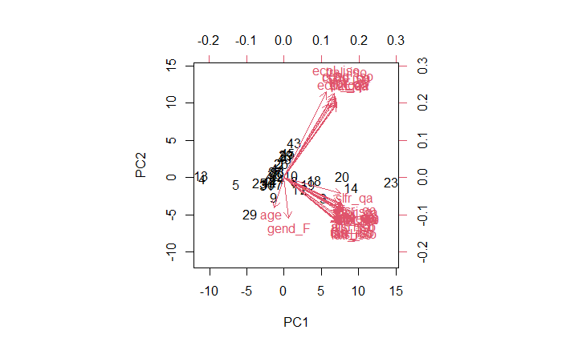

```r
#pca.out
biplot(pca.out, scale = 0)
```

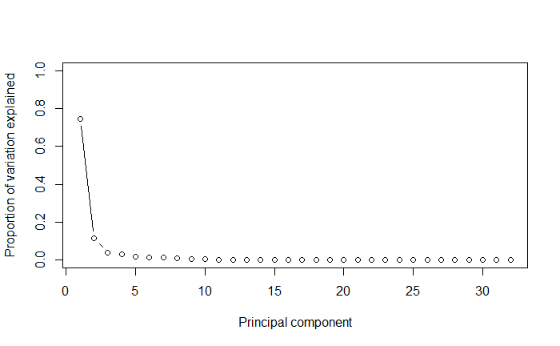

```r
pca.var <- pca.out$sdev^2

pve <- pca.var/sum(pca.var)
plot(pve, xlab = "Principal component",
     ylab = "Proportion of variation explained",
     ylim = c(0, 1),
     type = 'b')
```

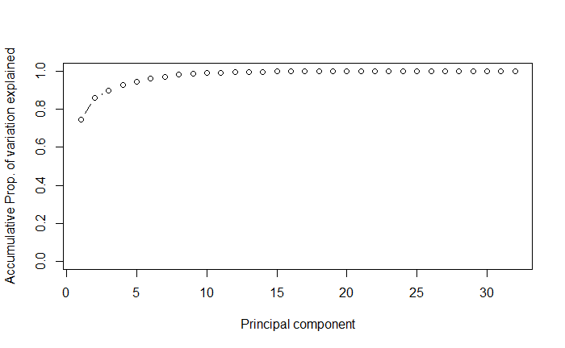

```r
plot(cumsum(pve), xlab = "Principal component",
     ylab = "Accumulative Prop. of variation explained",
     ylim = c(0, 1),
     type = 'b')
```

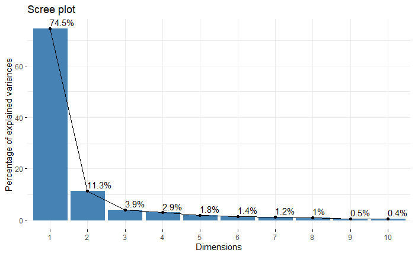

```r
library(factoextra)
fviz_screeplot(pca.out, addlabels = TRUE)
```

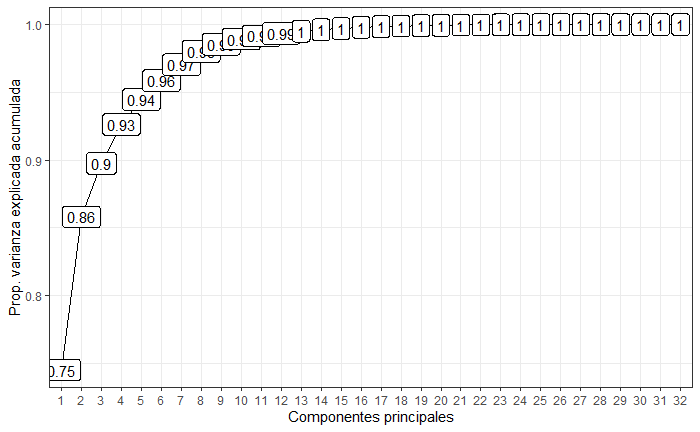

```r
# Cálculo de la varianza explicada acumulada
prop_varianza <- pca.out$sdev^2/sum(pca.out$sdev^2)
prop_varianza_acum <- cumsum(prop_varianza)
ggplot(data = data.frame(prop_varianza_acum, pc = factor(1:32)),
       aes(x = pc, y = prop_varianza_acum, group = 1)) +
  geom_point() +
  geom_line() +
  geom_label(aes(label = round(prop_varianza_acum,2))) +
  theme_bw() +
  labs(x = "Componentes principales",
       y = "Prop. varianza explicada acumulada")
```

```r
################################
# Construct new data frame with PCA selected compoents 1:10 ---------------
#training
midatos <- data.frame(A = training[, "A"], pca.out$x[, 1:2])

# Fit the logistic regressin model again ----------------------------------

logRegPCA <- glm(A ~ .,  data = midatos, family = binomial)

# Predict the scores on PC1 for the test set data
# head(testing)
test.p <- predict(pca.out, newdata = testing[, 1:33])
#head(test.p)

# Now use that to predict the class
pred <- predict(logRegPCA, newdata = data.frame(test.p[, 1:5]), type = "response")
summary(pred)
```

```
   Min. 1st Qu.  Median    Mean 3rd Qu.    Max.
 0.3303  0.6428  0.7730  0.6911  0.7952  0.8255
```

```r
#test.p[, 1:5]
# cross-classification table
predA <- factor(ifelse(pred >= 0.5, 1, 0))
#
table(predA)
```

```
predA
 0  1
 2 11
```

```r
table(testing$A)
```

```
0 1
5 8
```

```r
table(testing$A, predA)
```

```
   predA
    0 1
  0 0 5
  1 2 6
```

```r
testing$A
```

```
 [1] 0 0 1 1 1 1 1 1 1 0 0 0 1
```

```r
as.factor(predA)
```

```
 1  6 12 15 16 17 21 22 28 32 33 34 38
 1  1  1  1  1  1  1  1  0  1  1  1  0
Levels: 0 1
```

```r
confusionMatrix(testing$A, as.factor(predA))
```

```
Error: `data` and `reference` should be factors with the same levels.
```

### FORMA 2

```r
pca.out2 <- prcomp(t2[,c(-33)],
                  scale. = TRUE)
pca.out2
misdatos <- data.frame(A = t2[, "A"], pca.out2$x[, 1:2])
pca.out2[1]
logRegPCA <- glm(A ~ .,  data = misdatos, family = binomial)
summary(logRegPCA)
logistic.regression.or.ci(logRegPCA)
summary(logRegPCA)$coefficients
```

[output not shown]

## Etapa 2: Regresión Logística entre A y Confusoras

Aquí es un trabajo manual para cada prueba a realizar. Cada regresión tiene que ser ajustada.

```r
tag<-filter(t, label==0)
### MODELO 1
# Modelo de regresión logística
form = "A ~ age + gend_F + sl2l_iso + ecpl_iso"
form = formula(form)
model1 <- glm(form, data = tag, family = binomial())
summary(model1)
step(model1, direction = "backward")

### MODELO 2
form = "A ~ age + gend_F+ sl2l_iso"
form = formula(form)
model2 <- glm(form, data = tag, family = binomial())
summary(model2)
step(model2, direction = "backward")

logistic.regression.or.ci(model2)

# Bondad de ajuste del modelo Devianza y Chi2
# Para saber la eficacia del modelo prediciendo la variable respuesta utilizamos el estadístico chi-cuadrado, que mide la diferencia entre el modelo en su estado actual y el modelo cuando sólo se incluyó la constante.

dev <- model2$deviance
nullDev <- model2$null.deviance
modelChi <- nullDev - dev
modelChi


#como la probabilidad es menor que 0.05, podemos rechazar la hipótesis nula de que el modelo es mejor prediciendo la variable resultado que si elegimos por azar. Por tanto, podemos decir que, en general, el modelo tiene una aportación significativa en la perdición
chigl <- model2$df.null - model2$df.residual
chisq.prob <- 1 - pchisq(modelChi, chigl)
chisq.prob

# R^2
R2.hl <- modelChi/model2$null.deviance
R2.hl
#coeficientes y z-statistic
summary(model2)$coefficients

# Odds ratio
exp(model2$coefficients)
## intervalos de confianza
exp(confint(model2))


# Diagnóstico del modelo
tag$probabilidades.predichas <- fitted(model2)
tag$studentized.residuals <- rstudent(model2)
tag$dfbeta <- dfbeta(model2)
tag$dffit <- dffits(model2)
tag$leverage <- hatvalues(model2)

head(tag[, c("age", "sl2l_iso","probabilidades.predichas")])
head(tag[, c("leverage", "studentized.residuals", "dfbeta")])

# Selección del modelo
modelog <- glm(A ~ age+sl2l_iso, data = tag, family = binomial())
summary(modelog)
step(modelog, direction = "backward")

####################################################
# Supuestos del modelo Linealidad
tag$logageInt <- log(tag$age) * tag$age
tag$logsl2lInt <- log(tag$sl2l_iso) * tag$sl2l_iso
#df$logvar2Int <- log(df$var2) * df$var2
```

[output not shown]

### Generación de Z Score

Usar una de ellas. La que mejor se ajusta a los datos.

### Con PCA

```r
pca.out2[1]
```

```
$sdev
 [1] 4.83717667 1.98748001 1.09547284 0.91798992 0.72246034 0.68892921 0.67518031 0.57290040 0.49793973 0.32684182 0.29941743
[12] 0.26892246 0.22790199 0.21420238 0.20486389 0.18531915 0.17381661 0.14782992 0.13411891 0.12424134 0.11625807 0.10012812
[23] 0.08140791 0.07502309 0.06816247 0.05704939 0.05079271 0.04685678 0.04005271 0.02917233 0.02392420 0.01892836
```

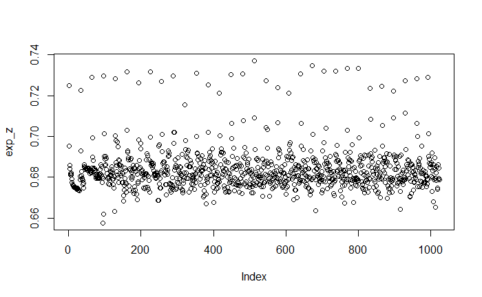

```r
exp_z <- 1/(1+exp(-(as.numeric(unlist(logRegPCA$coefficients[1]))+as.numeric(unlist(logRegPCA$coefficients[2]))*as.numeric(unlist(pca.out2[1]))+as.numeric(unlist(logRegPCA$coefficients[3]))*as.numeric(unlist(pca.out2[2])))))

plot(exp_z)
```

### SIN PCA

```r
### Utilizo el modelo 2
t<- t %>%
        mutate(zscore = (1/(1+exp(-(as.numeric(unlist(model2$coefficients[1]))+as.numeric(unlist(modelog$coefficients[2]))*data$age+as.numeric(unlist(model2$coefficients[3]))*data$sl2l_iso)))))
```

#### Armado de Subclases del Zscore para estudio posterior

Tener en cuenta que se puede dividir de manera diferente, por otra cantidad de estratos como por ejemplo spline.

```r
#########
# Entonces utilizo el total
t$subclass <- cut(x=t$zscore,
                              breaks=quantile(t$zscore,
                              prob = seq(0, 1, 1/5)),include.lowest=T)
levels(t$subclass) <- 1:length(levels(t$subclass))
#examine common support
xtabs(~A+subclass,t) #table of counts per stratum
```

```
   subclass
A    1  2  3  4  5
  0  7 10  5  8  8
  1 13  9 14 11 11
```

#### Generar Función constante por partes/escalonada Lambda

Aquí es una función que se obtiene de splines. No la tenemos todavía.

#### Generar Constante Delta

Se utiliza o genera despues de realizar la regresión

```r
#Regresion logística condicional o por estratos
reglog.cond <-clogit(label~A+strata(subclass),data=t)
summary(reglog.cond)
```

```
Call:
coxph(formula = Surv(rep(1, 96L), label) ~ A + strata(subclass),
    data = t, method = "exact")

  n= 96, number of events= 50

     coef exp(coef) se(coef)      z Pr(>|z|)
A -0.5873    0.5558   0.4300 -1.366    0.172

  exp(coef) exp(-coef) lower .95 upper .95
A    0.5558      1.799    0.2393     1.291

Concordance= 0.571  (se = 0.052 )
Likelihood ratio test= 1.9  on 1 df,   p=0.2
Wald test            = 1.87  on 1 df,   p=0.2
Score (logrank) test = 1.88  on 1 df,   p=0.2
```

```r
delta = coefficients(reglog.cond)[[1]]
```

## Modelo Final

El modelo final tiene algunas dificultades, con respecto a si es por cada sujeto o es el total de sujetos.

Deberíamos tener dos calculos

```r
# Función  constante por partes o escalonada
# La idea que entiuendo es: detras es que los valores de puntación de zscore está a partir de los sujetos de estudio, y se arma nudos para capturar las medias o puntos centrales.

# Definida en base a splines // buscando la función
# x<-zsc

#cuts <- c( -Inf, -1.793, -1.304, -0.326, 0.625, 1.630, 2.119 )
#vals <- c(    0,  0.454,      0,  0.632,     0, 0.227,     0 )
#fx <- vals[findInterval(x, c(-Inf, cuts))]
#f <- stepfun(cuts[-1], vals)
#fx <- f(x)
##################################################################
#función productoria
productoria <- function(D,delta,A,lamdaz){
   result = prod((exp(D*(delta*A)+lamdaz))/(1+exp((delta*A)+lamdaz)))
   return(result)
}
productoria(1,1,1,1)
```

```
[1] 0.8807971
```

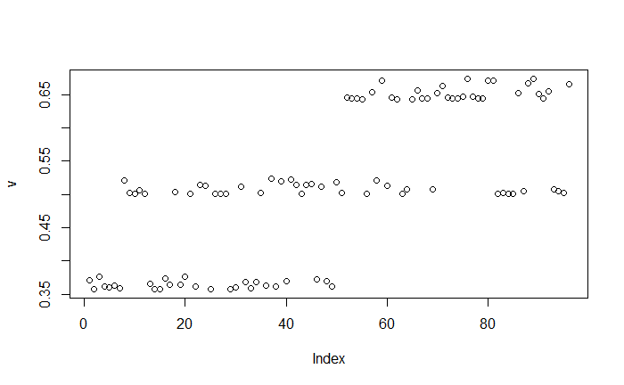

```r
## donde D es label donde es 1 = Patologia, 0 sin patología,
## delta es la varianza de regresion logística estratificada entre A y estratos de los cuantiles de la puntuación de zscore
##

v<-c()

# delta = -0.6558704 este valor de delta proviene de reg log estrat

for(i in 1:nrow(t)) {       # for-loop over rows
  v[i] <- (productoria(t[i,c("label")], delta, t[i,c("A")], t[i,c("zscore")]))
}

plot(v)
```